# Survey_descriptive_statistics

This workflow describe the results from the surveys during the workshops in Belize during Oct 2024

```r
library(dplyr)
```

### Import data

```r
Fishery_survey <- read_excel("~/Documents/GitHub_projects/Networks_SSF_NatCap/data/processed/survey_answers.xlsx", sheet = "Fishers")
```

## define output folders

```r
# Define the folder path
Fig_output_folder <- "C:/Users/jolaya/Documents/GitHub_projects/Networks_SSF_NatCap/results/figures"

Table_output_folder <- "C:/Users/jolaya/Documents/GitHub_projects/Networks_SSF_NatCap/results/tables"
```

## How many fishers participated in the worshops

```r
fisher_count <- Fishery_survey %>%
  group_by(Site, Gender) %>%              # Group by Site
  summarise(
    Unique_Fishers = n_distinct(ID)  # Count unique IDs per site
  )
# View the result
print(fisher_count)
```

| Site | Gender | Unique_Fishers |
| --- | --- | --- |
| Caye_Caulker | Female | 5 |
| Caye_Caulker | Male | 7 |
| Caye_Caulker | NA | 3 |
| Placencia | Female | 1 |
| Placencia | Male | 3 |
| Placencia | NA | 1 |

```r
# Export using base R
write.csv(fisher_count, file = file.path(Table_output_folder, "fisher_count_gender.csv"), row.names = FALSE)
```

## ethnicity

```r
# Summarize the unique number of fishers by Site and Ethnicity
unique_ethnicity_summary <- Fishery_survey %>%
  group_by(Site, Ethnicity) %>%         # Group by Site and Ethnicity
  summarise(
    Unique_Fishers = n_distinct(ID)     # Count unique fishers using their ID
  ) %>%
  arrange(Site, Ethnicity)              # Arrange the results for readability
# Reshape into a pivot table
ethnicity_pivot_table <- unique_ethnicity_summary %>%
  pivot_wider(
    names_from = Site,          # Columns: Site
    values_from = Unique_Fishers, # Values: Unique_Fishers count
    values_fill = 0             # Fill missing values with 0
  )

# View the pivot table
print(ethnicity_pivot_table)
```

| Ethnicity | Caye_Caulker | Placencia |
| --- | --- | --- |
| Creole | 3 | 3 |
| Garifuna | 1 | 1 |
| Maya | 1 | 0 |
| Mestizo | 3 | 0 |
| Mestizo, Creole | 3 | 0 |
| Mestizo, Maya | 1 | 0 |
| NA | 3 | 1 |

```r
# Export using base R
write.csv(ethnicity_pivot_table, file = file.path(Table_output_folder, "ethnicity_pivot_table.csv"), row.names = FALSE)
```

## age groups

```r
# Calculate the number of unique fishers in each age group for each site
age_group_counts <- aggregate(
  ID ~ Site + Age_group,
  data = Fishery_survey,
  FUN = function(x) { length(unique(x)) }
)

# Calculate the total number of unique fishers per site
total_fishers_per_site <- aggregate(
  ID ~ Site,
  data = Fishery_survey,
  FUN = function(x) { length(unique(x)) }
)

# Merge the data frames
merged_age_data <- merge(age_group_counts, total_fishers_per_site, by = "Site")

# Calculate the proportion of each age group within each site
merged_age_data$proportion <- merged_age_data$ID.x / merged_age_data$ID.y

# Rename columns for clarity
colnames(merged_age_data) <- c("Site", "Age_group", "Fisher_count_in_age_group", "Total_fishers", "Proportion")

# Print the results
print(merged_age_data)
```

| Site | Age_group | Fisher_count_in_age_group | Total_fishers | Proportion |
| --- | --- | --- | --- | --- |
| Caye_Caulker | >55 | 4 | 15 | 0.2666667 |
| Caye_Caulker | 25 - 34 | 4 | 15 | 0.2666667 |
| Caye_Caulker | 35 - 44 | 3 | 15 | 0.2000000 |
| Caye_Caulker | 45 - 54 | 2 | 15 | 0.1333333 |
| Placencia | 25 - 34 | 1 | 5 | 0.2000000 |
| Placencia | 35 - 44 | 1 | 5 | 0.2000000 |
| Placencia | 45 - 54 | 2 | 5 | 0.4000000 |

```r
# Export using base R
write.csv(merged_age_data, file = file.path(Table_output_folder, "Age_group_participation.csv"), row.names = FALSE)
```

## multy fishery

```r
# Group by ID and count unique fisheries per fisher
fishery_counts <- Fishery_survey %>%
  group_by(ID) %>%
  summarise(fisheries_count = n_distinct(Specie)) %>%
  ungroup()

# Categorize fishers based on the number of fisheries they participate in
Multi_fishery_summary <- fishery_counts %>%
  mutate(category = case_when(
    fisheries_count == 1 ~ "One fishery",
    fisheries_count == 2 ~ "Two fisheries",
    fisheries_count >= 3 ~ "All fisheries"
  )) %>%
  count(category, name = "fisher_count") %>%
  mutate(proportion = fisher_count / sum(fisher_count))

# View the summary
print(Multi_fishery_summary)
```

| category | fisher_count | proportion |
| --- | --- | --- |
| All fisheries | 13 | 0.65 |
| One fishery | 6 | 0.30 |
| Two fisheries | 1 | 0.05 |

```r
# Export using base R
write.csv(Multi_fishery_summary, file = file.path(Table_output_folder, "Multi_fishery_summary.csv"), row.names = FALSE)
```

## Most common fishing gear used

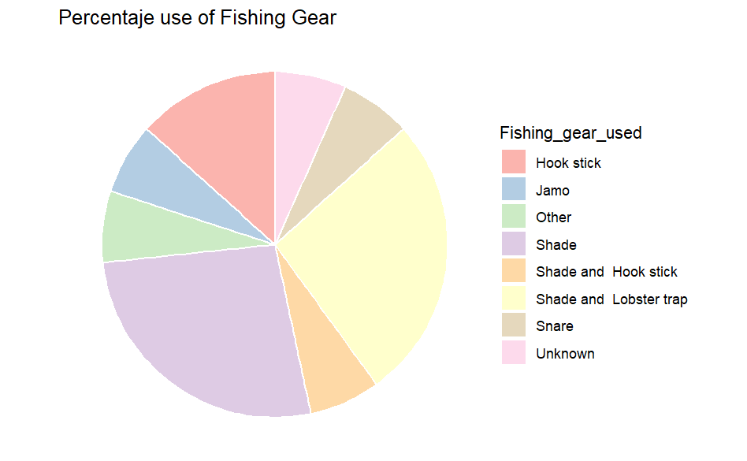

### Fishing zones

Determine the number of fishers fishing in each fishing zone, grouped by Site

```r
# Clean and expand the Fishing_zone column
zone_analysis <- Fishery_survey %>%
  filter(Specie == "Lobster") %>%
  filter(!is.na(Fishing_zone)) %>%  # Remove rows with NA in Fishing_zone
  separate_rows(Fishing_zone, sep = " and ") %>%  # Split multiple zones into separate rows
  group_by(Fishing_zone) %>%
  summarise(unique_fishers = n_distinct(ID), .groups = "drop") %>%  # Count unique fishers per zone per site
  arrange(Fishing_zone)  # Arrange results for clarity

# View the result
print(zone_analysis)
```

[output not shown]

### Own their vessel and gear

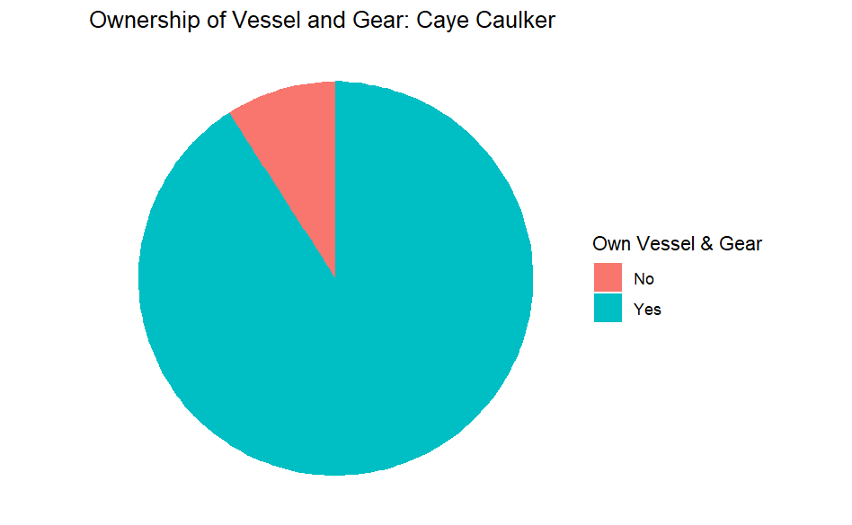

```r
# Filter data for Lobster
Lobster_data <- Fishery_survey %>%
  filter(Specie == "Lobster")

# Check if the dataset is empty
if (nrow(Lobster_data) == 0) {
  stop("No data found for Specie == 'Lobster'. Verify the data.")
}

# Function to prepare pie chart data
prepare_pie_data <- function(data, site_name = "All Sites") {
  data %>%
    filter(Site == site_name | site_name == "All Sites") %>%
    group_by(Own_vessel_gear) %>%
    summarize(Count = n(), .groups = "drop") %>%
    mutate(Percentage = Count / sum(Count) * 100)
}

# Prepare data for each site and all sites
caye_data <- prepare_pie_data(Lobster_data, "Caye_Calker")
placencia_data <- prepare_pie_data(Lobster_data, "Placencia")
all_sites_data <- prepare_pie_data(Lobster_data)

# Combine all datasets for plotting
pie_data <- bind_rows(caye_data, placencia_data, all_sites_data)

# Function to create a pie chart
create_pie_chart_with_percentages <- function(data, site_name) {
  ggplot(data, aes(x = "", y = Count, fill = Own_vessel_gear)) +
    geom_bar(stat = "identity", width = 1) +
    coord_polar("y", start = 0) +
    geom_text(aes(label = paste0(round(Percentage, 1), "%")),
              position = position_stack(vjust = 0.5), size = 4, color = "white") +
    labs(title = paste("Ownership of Vessel and Gear:", site_name),
         fill = "Own Vessel & Gear",
         x = NULL, y = NULL) +
    theme_void() +
    theme(legend.position = "right")
}

# Create pie charts for each site
plot_caye <- create_pie_chart(caye_data, "Caye Caulker")
plot_placencia <- create_pie_chart(placencia_data, "Placencia")
plot_all_sites <- create_pie_chart(all_sites_data, "All Sites")

# Display the plots
print(plot_caye)
```

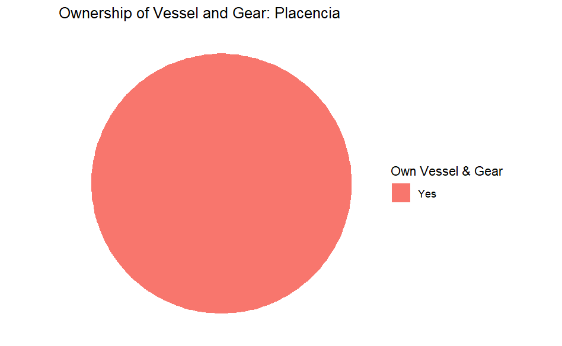

```r
print(plot_placencia)
```

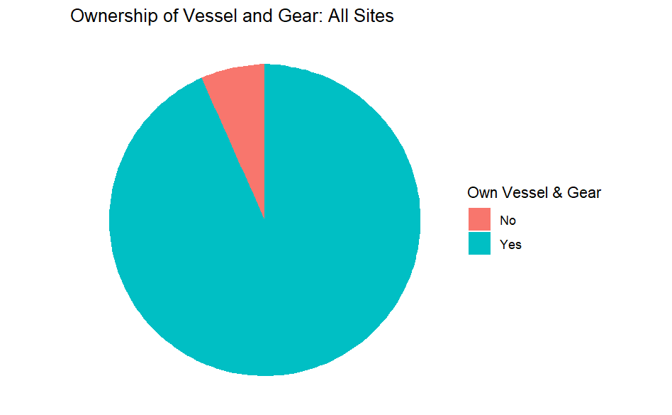

```r
print(plot_all_sites)
```

### Number of fishing trips per month

```r
# Calculate average number of fishing trips by Specie
average_trips <- Fishery_survey %>%
  group_by(Site, Specie) %>%
  summarise(
    average_monthly_effort = mean(Fishing_trips_per_month_season, na.rm = TRUE),
    sd_montlhy_effort = sd(Fishing_trips_per_month_season, na.rm = TRUE)
  )
# View the result
print(average_trips)
```

| Site | Specie | average_monthly_effort | sd_montlhy_effort |
| --- | --- | --- | --- |
| Caye_Caulker | Conch | 8.25000 | 9.019819 |
| Caye_Caulker | Finfish | 10.72222 | 9.711820 |
| Caye_Caulker | Lobster | 10.65000 | 7.527911 |
| Placencia | Conch | 3.87500 | 2.780138 |
| Placencia | Finfish | 8.25000 | 8.539126 |
| Placencia | Lobster | 13.25000 | 12.148388 |

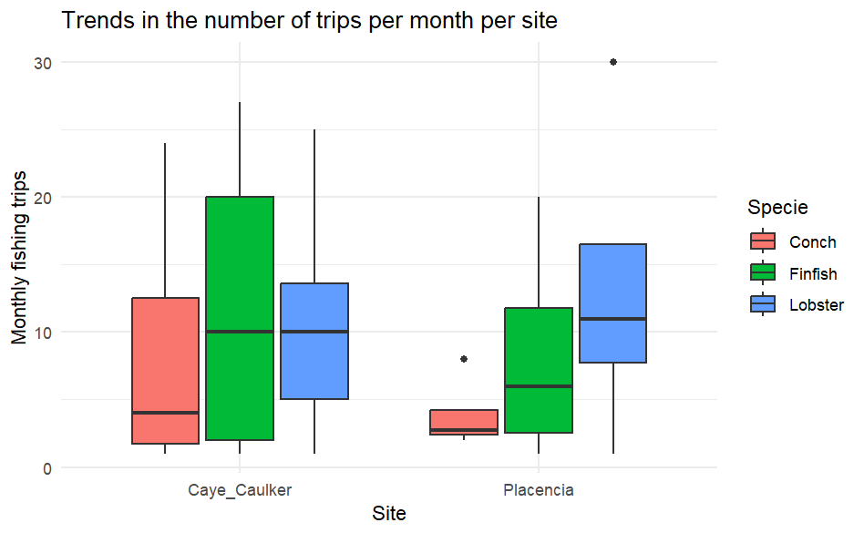

```r
# Export to CSV
write.csv(average_trips, file = file.path(Table_output_folder, "average_fishing_trips_by_specie.csv"), row.names = FALSE)

# Trends in the number of trips per month per site
monthly_effort <- ggplot(Fishery_survey, aes(x = Site, y = Fishing_trips_per_month_season, fill = Specie)) +
  geom_boxplot() +
  theme_minimal() +
  labs(title = "Trends in the number of trips per month per site", y = "Monthly fishing trips", x = "Site")

plot(monthly_effort)

ggsave(filename = file.path(Fig_output_folder, "Monthly_effort_specie.png"),
       plot = monthly_effort)
```

```r
# Calculate average number of fishing trips by Specie
average_catch <- Fishery_survey %>%
  group_by(Site, Specie) %>%
  summarise(
    average_catch_trip = mean(Average_catch_per_trip, na.rm = TRUE),
    sd_catch_trip = sd(Average_catch_per_trip, na.rm = TRUE)
  )
# View the result
print(average_catch)
```

| Site | Specie | average_catch_trip | sd_catch_trip |
| --- | --- | --- | --- |
| Caye_Caulker | Conch | 57.25000 | 65.12844 |
| Caye_Caulker | Finfish | 69.00000 | 21.33073 |
| Caye_Caulker | Lobster | 47.90625 | 38.62455 |
| Placencia | Conch | 301.25000 | 406.18397 |
| Placencia | Finfish | 180.62500 | 48.83540 |
| Placencia | Lobster | 106.25000 | 60.60459 |

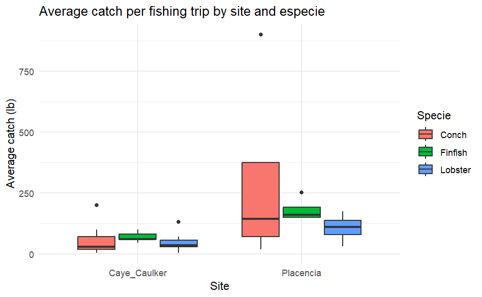

```r
# Export to CSV
write.csv(average_catch, file = file.path(Table_output_folder, "average_catch.csv"), row.names = FALSE)

# Trends in the average catch per fishing trips
monthly_catch <- ggplot(Fishery_survey, aes(x = Site, y = Average_catch_per_trip, fill = Specie)) +
  geom_boxplot() +
  theme_minimal() +
  labs(title = "Average catch per fishing trip by site and especie", y = "Average catch (lb)", x = "Site")

plot(monthly_catch)

ggsave(filename = file.path(Fig_output_folder, "Monthly_catch.png"),
       plot = monthly_catch)
```

## Average sell price

```r
# Calculate average selling price by Specie
average_sell <- Fishery_survey %>%
  group_by(Site, Specie) %>%
  summarise(
    average_sell_price = mean(Selling_price, na.rm = TRUE),
    sd_sell_price = sd(Selling_price, na.rm = TRUE)
  )
# View the result
print(average_sell)
```

| Site | Specie | average_sell_price | sd_sell_price |
| --- | --- | --- | --- |
| Caye_Caulker | Conch | 9.375000 | 3.2486261 |
| Caye_Caulker | Finfish | 10.985714 | 3.1360424 |
| Caye_Caulker | Lobster | 23.250000 | 6.9590640 |
| Placencia | Conch | 9.125000 | 0.8539126 |
| Placencia | Finfish | 6.777778 | 2.3412564 |
| Placencia | Lobster | 29.000000 | 1.1547005 |

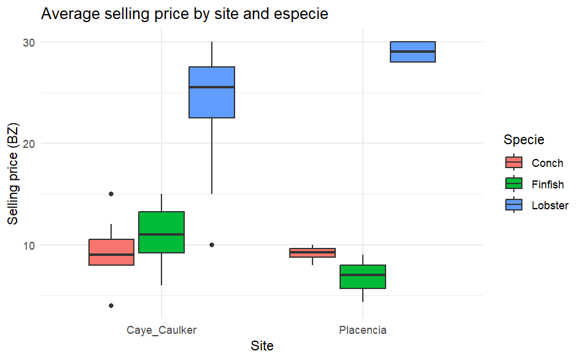

```r
# Export to CSV
write.csv(average_sell, file = file.path(Table_output_folder, "average_sell.csv"), row.names = FALSE)

# Trends in the average catch per fishing trips
plot_average_sell <- ggplot(Fishery_survey, aes(x = Site, y = Selling_price, fill = Specie)) +
  geom_boxplot() +
  theme_minimal() +
  labs(title = "Average selling price by site and especie", y = "Selling price (BZ)", x = "Site")

plot(plot_average_sell)

ggsave(filename = file.path(Fig_output_folder, "plot_average_sell.png"),
       plot = plot_average_sell)
```

### average profit from fishing trips

```r
# Calculate average profit fro fishing trips
average_profit <- Fishery_survey %>%
  group_by(Site, Specie) %>%
  summarise(
    average_profit = mean(Profit_from_trip, na.rm = TRUE),
    sd_profit = sd(Profit_from_trip, na.rm = TRUE)
  )
# View the result
print(average_profit)
```

| Site | Specie | average_profit | sd_profit |
| --- | --- | --- | --- |
| Caye_Caulker | Conch | 505.0000 | 621.5907 |
| Caye_Caulker | Finfish | 352.0000 | 196.2651 |
| Caye_Caulker | Lobster | 589.8433 | 498.1471 |
| Placencia | Conch | 877.5000 | 751.2379 |
| Placencia | Finfish | 806.2500 | 726.3995 |
| Placencia | Lobster | 858.2500 | 972.9194 |

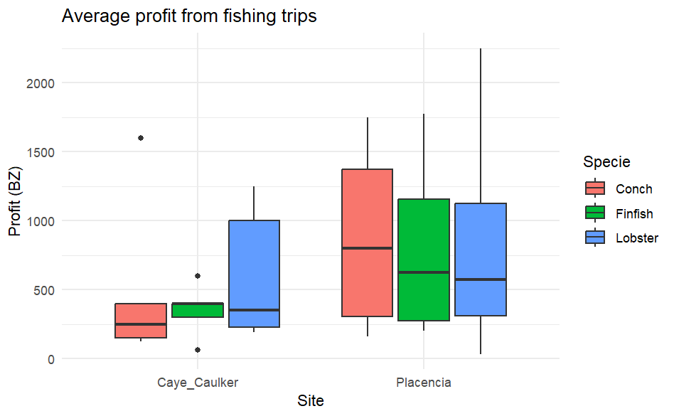

```r
# Export to CSV
write.csv(average_profit, file = file.path(Table_output_folder, "average_profit.csv"), row.names = FALSE)

# Trends in the average catch per fishing trips
plot_average_profit <- ggplot(Fishery_survey, aes(x = Site, y = Profit_from_trip, fill = Specie)) +
  geom_boxplot() +
  theme_minimal() +
  labs(title = "Average profit from fishing trips", y = "Profit (BZ)", x = "Site")

plot(plot_average_profit)

ggsave(filename = file.path(Fig_output_folder, "plot_average_profit.png"),
       plot = plot_average_profit)
```

### Buyers

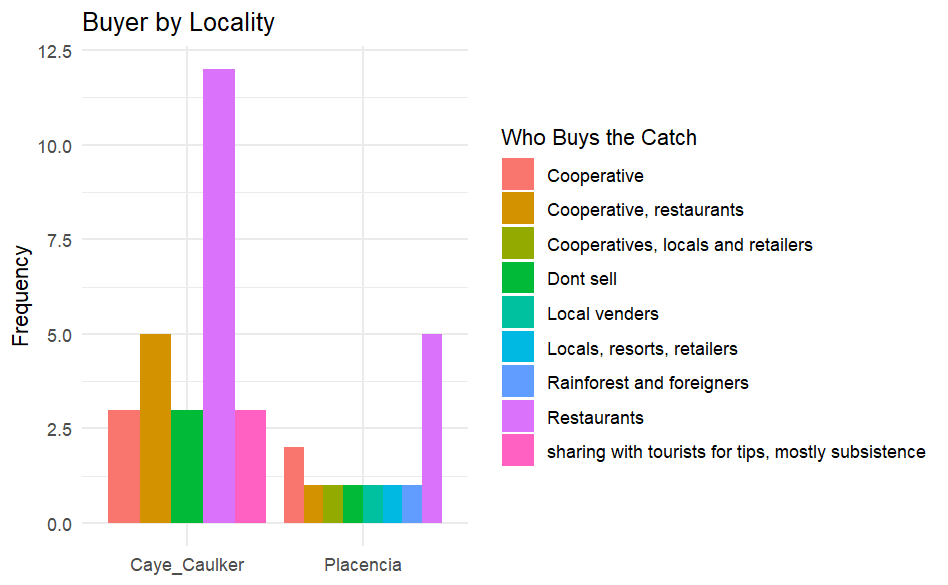

### Estimation of Fishers value added

We follow a production base approach.

is measured as the value of output minus the value of all intermediate inputs.

the value of output = the total sale of catch at ex-vessel price (the price that fishers report as selling price)

the value of intermediate inputs = costs such as fuel, ice, and vessel maintenance (reported by fishers as fishing trip cost).

The difference, which includes income for the fishers and crew and profit for the vessel owner, is the value-added to the economy (Grafeld et al., 2017).

### estimation of total catch per season (year)

```r
# Define the season months for each species
Fishery_survey <- Fishery_survey %>%
  mutate(
    season_months = case_when(
      Specie == "Lobster" ~ 8,
      Specie == "Conch" ~ 8,
      Specie == "Finfish" ~ 12,
      TRUE ~ NA_real_  # Handle cases where Specie doesn't match
    )
  )

# Calculate total catch per season
catch_survey <- Fishery_survey %>%
  mutate(
    monthly_catch = Fishing_trips_per_month_season * Average_catch_per_trip,
    total_catch = monthly_catch * season_months, # Total catch for the season
    Total_Fishing_Trips = Fishing_trips_per_month_season * season_months #total effort season
  ) %>%
  dplyr::select(Site, Specie, ID, monthly_catch, total_catch, Selling_price, Total_Fishing_Trips, Fishing_trip_cost)  # Select relevant columns for review

# Summarize total catch by species
catch_survey_summary <- catch_survey %>%
  group_by(Site, Specie) %>%
  summarise(
    avg_catch_season = mean(total_catch, na.rm = TRUE),
    Avg_Selling_Price = mean(Selling_price, na.rm = TRUE),
    Avg_effort = mean(Total_Fishing_Trips, na.rm = TRUE),
    Avg_trip_cost = mean(Fishing_trip_cost, na.rm = TRUE)
  )
# View the result
print(catch_survey_summary)
```

| Site | Specie | avg_catch_season | Avg_Selling_Price | Avg_effort | Avg_trip_cost |
| --- | --- | --- | --- | --- | --- |
| Caye_Caulker | Conch | 2610.286 | 9.375000 | 66.0000 | 281.2500 |
| Caye_Caulker | Finfish | 5088.000 | 10.985714 | 128.6667 | 265.0000 |
| Caye_Caulker | Lobster | 4850.000 | 23.250000 | 85.2000 | 277.7778 |
| Placencia | Conch | 6330.000 | 9.125000 | 31.0000 | 392.5000 |
| Placencia | Finfish | 15832.500 | 6.777778 | 99.0000 | 366.8750 |
| Placencia | Lobster | 13910.000 | 29.000000 | 106.0000 | 400.0000 |

```r
# Export using base R
write.csv(catch_survey_summary, file = file.path(Table_output_folder, "Seasonal_catch_summary.csv"), row.names = FALSE)
```

Estimate the total output and intermediate inputs in both places by multiply those averages by the total number of licensed fishers (data from Updated_list_for_WWF_Sept_2024).

Caye Caulker: 197 fishers

Placencia: 151 fishers

```r
# Multiply Average_Catch based on Site
Total_catch <- catch_survey_summary %>%
  mutate(Total_Catch = ifelse(Site == "Caye_Caulker", avg_catch_season * 197,
                                ifelse(Site == "Placencia", avg_catch_season * 151)),
         Total_effort = ifelse(Site == "Caye_Caulker", Avg_effort * 197,
                                ifelse(Site == "Placencia", Avg_effort * 151)
                               ),
         Total_output = Total_Catch * Avg_Selling_Price,
         Total_input = Total_effort * Avg_trip_cost,
         Value_added = Total_output - Total_input
         ) %>%
  dplyr::select(Site, Specie, Total_Catch, Total_output, Total_input, Value_added)

# Display the updated data frame
print(Total_catch)
```

| Site | Specie | Total_Catch | Total_output | Total_input | Value_added |
| --- | --- | --- | --- | --- | --- |
| Caye_Caulker | Conch | 514226.3 | 4820871 | 3656813 | 1164059 |
| Caye_Caulker | Finfish | 1002336.0 | 11011377 | 6717043 | 4294334 |
| Caye_Caulker | Lobster | 955450.0 | 22214213 | 4662333 | 17551879 |
| Placencia | Conch | 955830.0 | 8721949 | 1837293 | 6884656 |
| Placencia | Finfish | 2390707.5 | 16203684 | 5484414 | 10719270 |
| Placencia | Lobster | 2100410.0 | 60911890 | 6402400 | 54509490 |

```r
Total_catch_BZ <- catch_survey_summary %>%
  mutate(Total_Catch =  avg_catch_season * 3460,
         Total_effort = Avg_effort * 3460,
         Total_output = Total_Catch * Avg_Selling_Price,
         Total_input = Total_effort * Avg_trip_cost,
         Value_added = Total_output - Total_input
         ) %>%
  dplyr::select(Specie, Total_Catch, Total_output, Total_input, Value_added)
# Display the updated data frame
print(Total_catch_BZ)
```

| Site | Specie | Total_Catch | Total_output | Total_input | Value_added |
| --- | --- | --- | --- | --- | --- |
| Caye_Caulker | Conch | 9031589 | 84671143 | 64226250 | 20444893 |
| Caye_Caulker | Finfish | 17604480 | 193397787 | 117974467 | 75423321 |
| Caye_Caulker | Lobster | 16781000 | 390158250 | 81886667 | 308271583 |
| Placencia | Conch | 21901800 | 199853925 | 42099550 | 157754375 |
| Placencia | Finfish | 54780450 | 371289717 | 125669363 | 245620354 |
| Placencia | Lobster | 48128600 | 1395729400 | 146704000 | 1249025400 |

## make tables

```r
table1 <- flextable(age_groups) %>%
  set_caption("Table 1: Age group of participants during the workshops") %>%
  theme_vanilla() %>%
  autofit() %>%
  color(i = 1, color = "white", part = "header") %>%
  bold(part = "header") %>%
  bg(i = 1, bg = "grey", part = "header") %>%
  border_outer() %>%
  border_inner()

## table 2
# Engagement in multispecific fisheries by participants
table2 <- flextable(Multi_fishery_summary) %>%
  set_caption("Table 2: Engagement in multispecific fisheries by participants") %>%
  theme_vanilla() %>%
  autofit() %>%
  color(i = 1, color = "white", part = "header") %>%
  bold(part = "header") %>%
  bg(i = 1, bg = "grey", part = "header") %>%
  border_outer() %>%
  border_inner()



## table 3
tabla3 <- flextable(lobster_counts) %>%
  set_caption("Table 3: Fishing Gear used in Lobster Fishery") %>%
  theme_vanilla() %>%
  autofit() %>%
  color(i = 1, color = "white", part = "header") %>%
  bold(part = "header") %>%
  bg(i = 1, bg = "grey", part = "header") %>%
  border_outer() %>%
  border_inner()

# table 4
tabla4 <- flextable(fish_counts) %>%
  set_caption("Table 4: Fishing Gear used in Finsish Fishery") %>%
  theme_vanilla() %>%
  autofit() %>%
  color(i = 1, color = "white", part = "header") %>%
  bold(part = "header") %>%
  bg(i = 1, bg = "grey", part = "header") %>%
  border_outer() %>%
  border_inner()

# tabla5
tabla5 <- flextable(conch_counts) %>%
  set_caption("Table 5: Fishing Gear used in Queen Conch Fishery") %>%
  theme_vanilla() %>%
  autofit() %>%
  color(i = 1, color = "white", part = "header") %>%
  bold(part = "header") %>%
  bg(i = 1, bg = "grey", part = "header") %>%
  border_outer() %>%
  border_inner()

# tabla6
tabla6 <- flextable(average_trips) %>%
  set_caption("Table 6: Montlhy Fishing Effort") %>%
  theme_vanilla() %>%
  autofit() %>%
  color(i = 1, color = "white", part = "header") %>%
  bold(part = "header") %>%
  bg(i = 1, bg = "grey", part = "header") %>%
  border_outer() %>%
  border_inner()

# tabla7
tabla7 <- flextable(average_catch) %>%
  set_caption("Table 7: Average catch in the three fisheries") %>%
  theme_vanilla() %>%
  autofit() %>%
  color(i = 1, color = "white", part = "header") %>%
  bold(part = "header") %>%
  bg(i = 1, bg = "grey", part = "header") %>%
  border_outer() %>%
  border_inner()

# tabla8
tabla8 <- flextable(average_sell) %>%
  set_caption("Table 8: Average primary landing selling price") %>%
  theme_vanilla() %>%
  autofit() %>%
  color(i = 1, color = "white", part = "header") %>%
  bold(part = "header") %>%
  bg(i = 1, bg = "grey", part = "header") %>%
  border_outer() %>%
  border_inner()

# tabla9
tabla9 <- flextable(average_profit) %>%
  set_caption("Table 9: Average profit from fishing trips") %>%
  theme_vanilla() %>%
  autofit() %>%
  color(i = 1, color = "white", part = "header") %>%
  bold(part = "header") %>%
  bg(i = 1, bg = "grey", part = "header") %>%
  border_outer() %>%
  border_inner()

# Crear el documento de Word con ambas tablas
doc <- read_docx() %>%
  body_add_flextable(table1) %>%
  body_add_par("") %>%  # Espacio entre tablas
  body_add_flextable(table2)  %>%
  body_add_par("") %>%  # Espacio entre tablas
  body_add_flextable(tabla3) %>%
  body_add_par("") %>%  # Espacio entre tablas
  body_add_flextable(tabla4) %>%
  body_add_par("") %>%  # Espacio entre tablas
  body_add_flextable(tabla5) %>%
  body_add_par("") %>%  # Espacio entre tablas
  body_add_flextable(tabla6) %>%
  body_add_par("") %>%  # Espacio entre tablas
  body_add_flextable(tabla7) %>%
  body_add_par("") %>%  # Espacio entre tablas
  body_add_flextable(tabla8) %>%
  body_add_par("") %>%  # Espacio entre tablas
  body_add_flextable(tabla9)
print(doc, target = "Tabla_Artes_Pesca.docx")
```

RETAILERS

```r
# make table
Retailes_survey <- read_csv("~/Documents/GitHub_projects/Networks_SSF_NatCap/data/processed/Retailes_survey.csv")
```

```r
# Transformar los datos para hacer una tabla más ordenada
df <- data.frame(
  Species = c("Lobster", "Conch", "Snook", "Barracuda", "Snapper", "Grouper", "Wrasses", "Jacks"),
  Purchase_Quantity = c(NA, 10, NA, NA, 20, 30, NA, 10),
  Purchase_Price = c(28, 9.5, 10, 7, 10, 10, 10, NA),
  Selling_Price = c(29.3, 10.0, 10.7, 6.0, 8.7, 8.7, NA, 6.7)
)

# 🔹 Crear la tabla con flextable
tabla <- df %>%
  flextable() %>%
  set_caption("📊 Table: Purchase and Selling Prices of Fish Species") %>%
  theme_vanilla() %>%
  autofit() %>%
  bold(part = "header") %>%
  bg(i = 1, bg = "grey", part = "header") %>%
  color(i = 1, color = "white", part = "header") %>%
  border_outer() %>%
  border_inner()

# 🔹 Exportar la tabla a un documento Word
doc <- read_docx() %>%
  body_add_par("📘 Report on Fish Species Prices", style = "heading 1") %>%
  body_add_flextable(tabla)

print(doc, target = "Fish_Species_Prices.docx")
```

```r
df <- data.frame(
  Species = c("Lobster", "Conch", "Snook", "Barracuda", "Snapper", "Grouper", "Wrasses", "Jacks"),
  Consumers_Placencia = c(7, 8, 3, 9, 11, 6, 0, 6),
  Avg_Consumption_Placencia = c(6, 4, 10, 14, 10, 14, 0, 12),
  Consumers_Caye_Caulker = c(4, 6, 1, 2, 6, 1, 0, 2),
  Avg_Consumption_Caye_Caulker = c(3.8, 2.3, 1.0, 2.0, 2.9, 8.0, 0.0, 2.0)
)

# 🔹 Crear la tabla con flextable
tabla <- df %>%
  flextable() %>%
  set_caption("📊 Comparison of Seafood Consumption in Placencia and Caye Caulker") %>%
  theme_vanilla() %>%
  autofit() %>%
  bold(part = "header") %>%
  bg(i = 1, bg = "grey", part = "header") %>%
  color(i = 1, color = "white", part = "header") %>%
  border_outer() %>%
  border_inner()

# 🔹 Exportar la tabla a un documento Word
doc <- read_docx() %>%
  body_add_par("📘 Seafood Consumption Report", style = "heading 1") %>%
  body_add_flextable(tabla)

print(doc, target = "Seafood_Consumption_Report.docx")
```

```r
df <- data.frame(
  Institution = c(
    "WWF (Caye Caulker & Placencia)",
    "Fragments of Hope",
    "Caye Caulker BTIAC",
    "Belioness",
    "Humana People to People",
    "Southern Environmental Association",
    "Toledo Institute for Development and Environment"
  ),
  Primary_Role = c(
    "Community Engagement & Conservation Planning",
    "Site Coordinator",
    "Chairperson",
    "Vice Chair",
    "Grant Proposal Writing & Project Management",
    "Executive Director & Board Chairman",
    "Protected Area Manager"
  ),
  Impact_on_Fishers_Income = c(
    "Training in alternative livelihoods, income diversification",
    "Training fishers in monitoring & conservation",
    "Training, quality control, best practices",
    "Lionfish population monitoring",
    "Sustainable development training, funding for alternative livelihoods",
    "Capacity building & best practices training",
    "Managed access programs for traditional fishers"
  ),
  Measurement_of_Success = c(
    "Surveys, economic impact tracking",
    "Not quantified",
    "Number of fishers participating in programs",
    "Changes in lionfish abundance",
    "Improved community economic conditions",
    "Tracking fisher compliance with regulations",
    "Expansion into tourism-related activities"
  )
)

# 🔹 Create the flextable with formatting
tabla <- df %>%
  flextable() %>%
  set_caption("Strategies of Institutions to Improve Fishers' Livelihoods") %>%
  theme_vanilla() %>%
  autofit() %>%
  bold(part = "header") %>%
  bg(i = 1, bg = "grey", part = "header") %>%
  color(i = 1, color = "white", part = "header") %>%
  border_outer() %>%
  border_inner()

# 🔹 Export the table to a Word document
doc <- read_docx() %>%
  body_add_par("Report on Institutional Strategies for Fisheries", style = "heading 1") %>%
  body_add_flextable(tabla)

print(doc, target = "Institutional_Strategies_Fisheries.docx")
```

[output not shown]